# COVID19 Mortality rate prediction. IML ’20 Homework 2.

Łukasz Grad

Read and show raw data.

```r
covid %>% head()
```

| ID | age | sex | city | province | country | wuhan(0)_not_wuhan(1) | latitude | longitude | geo_resolution | date_onset_symptoms | date_admission_hospital | date_confirmation | symptoms | lives_in_Wuhan | travel_history_dates | travel_history_location | reported_market_exposure | additional_information | chronic_disease_binary | chronic_disease | source | sequence_available | outcome | date_death_or_discharge | notes_for_discussion | location | admin3 | admin2 | admin1 | … |
| --- | --- | --- | --- | --- | --- | --- | --- | --- | --- | --- | --- | --- | --- | --- | --- | --- | --- | --- | --- | --- | --- | --- | --- | --- | --- | --- | --- | --- | --- | --- |
| NA | NA | NA | NA | Tucuman | Argentina | NA | -26.94000 | -65.34000 | admin1 | NA | NA | 22.03.2020 | NA | NA | NA | NA | NA | NA | NA | NA | https://www.infobae.com/coronavirus/2020/03/22/confirmaron-41-nuevos-casos-de-coronavirus-en-la-argentina-y-el-total-de-infectados-asciende-a-266/ | NA | NA | NA | NA | NA | NA | NA | NA | … |
| NA | NA | NA | NA | Buenos Aires | Argentina | NA | -34.60333 | -58.38167 | admin1 | NA | NA | 22.03.2020 | NA | NA | NA | NA | NA | NA | NA | NA | https://www.infobae.com/coronavirus/2020/03/22/confirmaron-41-nuevos-casos-de-coronavirus-en-la-argentina-y-el-total-de-infectados-asciende-a-266/ | NA | NA | NA | NA | NA | NA | NA | NA | … |
| NA | NA | NA | NA | Buenos Aires | Argentina | NA | -34.60333 | -58.38167 | admin1 | NA | NA | 22.03.2020 | NA | NA | NA | NA | NA | NA | NA | NA | https://www.infobae.com/coronavirus/2020/03/22/confirmaron-41-nuevos-casos-de-coronavirus-en-la-argentina-y-el-total-de-infectados-asciende-a-266/ | NA | NA | NA | NA | NA | NA | NA | NA | … |
| NA | NA | NA | NA | Buenos Aires | Argentina | NA | -34.60333 | -58.38167 | admin1 | NA | NA | 22.03.2020 | NA | NA | NA | NA | NA | NA | NA | NA | https://www.infobae.com/coronavirus/2020/03/22/confirmaron-41-nuevos-casos-de-coronavirus-en-la-argentina-y-el-total-de-infectados-asciende-a-266/ | NA | NA | NA | NA | NA | NA | NA | NA | … |
| NA | NA | NA | NA | Cordoba | Argentina | NA | -31.41667 | -64.18333 | admin1 | NA | NA | 22.03.2020 | NA | NA | NA | NA | NA | NA | NA | NA | https://www.infobae.com/coronavirus/2020/03/22/confirmaron-41-nuevos-casos-de-coronavirus-en-la-argentina-y-el-total-de-infectados-asciende-a-266/ | NA | NA | NA | NA | NA | NA | NA | NA | … |
| NA | NA | NA | NA | Cordoba | Argentina | NA | -31.41667 | -64.18333 | admin1 | NA | NA | 22.03.2020 | NA | NA | NA | NA | NA | NA | NA | NA | https://www.infobae.com/coronavirus/2020/03/22/confirmaron-41-nuevos-casos-de-coronavirus-en-la-argentina-y-el-total-de-infectados-asciende-a-266/ | NA | NA | NA | NA | NA | NA | NA | NA | … |

We have a lot of missing values and data in general is messy. The column of interest is “outcome”

```r
covid %>%
    summarise_all(~ mean(is.na(.)))
```

| ID | age | sex | city | province | country | wuhan(0)_not_wuhan(1) | latitude | longitude | geo_resolution | date_onset_symptoms | date_admission_hospital | date_confirmation | symptoms | lives_in_Wuhan | travel_history_dates | travel_history_location | reported_market_exposure | additional_information | chronic_disease_binary | chronic_disease | source | sequence_available | outcome | date_death_or_discharge | notes_for_discussion | location | admin3 | admin2 | admin1 | … |
| --- | --- | --- | --- | --- | --- | --- | --- | --- | --- | --- | --- | --- | --- | --- | --- | --- | --- | --- | --- | --- | --- | --- | --- | --- | --- | --- | --- | --- | --- | --- |
| 0.001855055 | 0.9591027 | 0.9599637 | 0.5469517 | 0.0769574 | 0.0003913619 | 0.4957537 | 0.1319124 | 0.1319594 | 0.1271143 | 0.9918127 | 0.9923137 | 0.009541402 | 0.9920397 | 0.9851517 | 0.9939887 | 0.9789447 | 0.9906465 | 0.9664525 | 0.9955541 | 1 | 0.05415665 | 0.9913431 | 0.9973935 | 0.9981997 | 0.9976597 | 0.9801658 | 0.9140413 | 0.5891718 | 0.4632159 | … |

We have 99 cases of confirmed deaths.

```r
# A tiny bit of cheating to increase positive sample size
death_vals = c('death', 'died',
               'treated in an intensive care unit (14.02.2020)',
               'critical condition, intubated as of 14.02.2020')
covid %>% filter(outcome %in% death_vals)
```

| ID | age | sex | city | province | country | wuhan(0)_not_wuhan(1) | latitude | longitude | geo_resolution | date_onset_symptoms | date_admission_hospital | date_confirmation | symptoms | lives_in_Wuhan | travel_history_dates | travel_history_location | reported_market_exposure | additional_information | chronic_disease_binary | chronic_disease | source | sequence_available | outcome | date_death_or_discharge | notes_for_discussion | location | admin3 | admin2 | admin1 | … |
| --- | --- | --- | --- | --- | --- | --- | --- | --- | --- | --- | --- | --- | --- | --- | --- | --- | --- | --- | --- | --- | --- | --- | --- | --- | --- | --- | --- | --- | --- | --- |
| 000-1-11272 | 80-89 | female | NA | Kanagawa Prefecture | Japan | 1 | 35.415570 | 139.339000 | admin1 | 22.01.2020 | 01.02.2020 | 13.02.2020 | anorexia, fatigue | NA | NA | NA | NA | Case 27; | NA | NA | https://www.mhlw.go.jp/stf/newpage_09503.html | NA | death | 13.02.2020 | NA | NA | NA | NA | Kanagawa Prefecture | … |
| 000-1-11282 | 50-59 | male | NA | Hokkaido | Japan | 1 | 43.402000 | 142.557100 | admin1 | 31.01.2020 | NA | 14.02.2020 | cough, fever, malaise | NA | NA | NA | NA | severe symptoms and are treated in an intensive care unit | NA | NA | https://www3.nhk.or.jp/news/html/20200214/k10012286451000.html | NA | treated in an intensive care unit (14.02.2020) | NA | NA | NA | NA | NA | Hokkaido | … |
| 000-1-11321 | 60-69 | male | NA | Taiwan | NA | 1 | 23.759470 | 120.955900 | admin1 | 27.01.2020 | 03.02.2020 | 15.02.2020 | cough, shortness of breath | NA | NA | NA | NA | NA | 1 | NA | https://www.cdc.gov.tw/Bulletin/Detail/C7SfkryzIXWf0eF_1O03hw?typeid=9 | NA | death | 15.02.2020 | NA | NA | NA | NA | Taiwan (Province of China) | … |
| 000-1-11498 | NA | NA | Qom | Qom | Iran | 1 | 34.640000 | 50.876390 | point | NA | NA | 19.02.2020 | NA | NA | NA | NA | NA | NA | NA | NA | https://www.channelnewsasia.com/news/world/covid-19-iran-middle-east-death-12451864 | NA | death | 19.02.2020 | NA | Qom | NA | NA | Qom | … |
| 000-1-11499 | NA | NA | Qom | Qom | Iran | 1 | 34.640000 | 50.876390 | point | NA | NA | 19.02.2020 | NA | NA | NA | NA | NA | NA | NA | NA | https://www.channelnewsasia.com/news/world/covid-19-iran-middle-east-death-12451864 | NA | death | 19.02.2020 | NA | Qom | NA | NA | Qom | … |
| 000-1-11525 | 77 | female | Codogno | Lombardia | Italy | 1 | 45.161100 | 9.701432 | point | NA | NA | 21.02.2020 | NA | NA | NA | NA | NA | Patient at Codogno hospital | NA | NA | https://milano.corriere.it/notizie/cronaca/20_febbraio_21/coronavirus-primo-contagio-lombardia-38enne-ricoverato-terapia-intensiva-9bc70b7e-543c-11ea-a963-13c45ec676cd.shtml (b) https://www.tgcom24.me… | NA | death | 22.02.2020 | NA | Codogno | NA | NA | Lombardia | … |
| 000-1-11526 | 78 | male | Vo Euganeo | Veneto | Italy | 1 | 45.297748 | 11.658382 | point | NA | NA | 21.02.2020 | NA | NA | NA | NA | NA | Hospitalized on 12.02.2020 for other reasons | NA | NA | https://www.corriere.it/cronache/20_febbraio_21/coronavirus-italia-cosa-sappiamo-casi-codogno-lombardia-27fa736c-548b-11ea-9196-da7d305401b7.shtml | NA | death | 22.02.2020 | NA | Vo' Euganeo | NA | NA | Veneto | … |
| 000-1-11528 | 68 | female | Cremona | Lombardia | Italy | 1 | 45.133330 | 10.033330 | point | NA | NA | 21.02.2020 | NA | NA | NA | NA | NA | NA | NA | NA | https://www.ansa.it/canale_saluteebenessere/notizie/sanita/2020/02/21/coronavirus-sono-tre-i-primi-contagiati-in-italia.-uno-e-molto-grave_4566075c-ee89-411d-8b3a-56b6b8246fc9.html (b) https://www.cor… | NA | death | 23.02.2020 | I believe is Cremona, not Codogno | Cremona | NA | NA | Lombardia | … |
| 000-1-13449 | 88 | male | NA | NA | San Marino | 1 | 43.939070 | 12.461000 | admin0 | NA | 25.02.2020 | 27.02.2020 | NA | NA | NA | none | NA | Already hospitalized in Rimini on 25.02.2020 | NA | NA | https://www.altarimini.it/News132152-coronavirus-primo-caso-nella-repubblica-di-san-marino.php (b) https://www.sanmarinortv.sm/news/attualita-c4/coronavirus-e-morto-il-sammarinese-ricoverato-a-rimini-… | NA | death | 01.03.2020 | NA | NA | NA | NA | NA | … |
| 000-1-13450 | 95 | female | Macquarie Park | New South Wales | Australia | 1 | -33.777200 | 151.124100 | point | NA | NA | 04.03.2020 | NA | NA | NA | NA | NA | Detected post mortem | NA | NA | https://www.health.nsw.gov.au/news/Pages/20200304_06.aspx | NA | death | 03.03.2020 | NA | Macquarie Park | NA | NA | New South Wales | … |

[output cut: 89 more lines]

Let’s see the most common early symptoms

```r
symptoms_data = lapply(covid$symptoms, clean_string)
symptoms_all = Reduce(c, symptoms_data)
symptoms_all_sorted = sort(table(symptoms_all), decreasing = T)
symptoms_all_sorted[1:15]
```

```
## symptoms_all
##    fever    cough     sore   throat     mild  fatigue headache     pain
##      525      312       63       60       49       39       37       33
##  malaise      and       of   chills     nose    runny   breath
##       25       24       24       23       23       21       19
```

Prepare clean dataset.

```r
frequent_countries = c('china', 'united states')
frequent_symptoms = c('pneumonia|pneumonitis', 'pain', 'fever',
                      'cough', 'sore throat', 'fatigue', 'headache', 'dyspnea')

covid_train = covid %>%
    mutate(
        outcome = ifelse(outcome %in% death_vals, 'dead', 'recovered'),
        country = ifelse(tolower(country) %in% frequent_countries, country, 'other'),
        in_wuhan = !as.logical(`wuhan(0)_not_wuhan(1)`),
        age = ifelse(str_detect(age, "[:digit:]{2}-[:digit:]{2}"),
                     0.5 * as.numeric(str_sub(age, 1, 2)) + 0.5 * as.numeric(str_sub(age, 3, 4)),
                     as.numeric(age)),
        sex = tolower(sex),
        chronic_disease = ifelse(is.na(chronic_disease_binary),
                                 'NA',
                                 ifelse(chronic_disease_binary == '1', '1', '0'))
    ) %>%
    select(age, sex, country, chronic_disease, outcome, in_wuhan, symptoms) %>%
    filter(!is.na(age)) %>%
    filter(!is.na(sex))
for (symptom in frequent_symptoms) {
    covid_train[symptom] = str_detect(symptom, covid_train$symptoms)
    covid_train[symptom][is.na(covid_train[symptom])] = F
}

covid_train = covid_train %>% select(-symptoms)

covid_train %>% head
```

| age | sex | country | chronic_disease | outcome | in_wuhan | pneumonia\|pneumonitis | pain | fever | cough | sore throat | fatigue | headache | dyspnea |
| --- | --- | --- | --- | --- | --- | --- | --- | --- | --- | --- | --- | --- | --- |
| 23.0 | male | other | NA | recovered | NA | FALSE | FALSE | FALSE | FALSE | FALSE | FALSE | FALSE | FALSE |
| 64.0 | male | other | 0 | recovered | NA | FALSE | FALSE | FALSE | FALSE | FALSE | FALSE | FALSE | FALSE |
| 53.0 | female | other | NA | recovered | NA | FALSE | FALSE | FALSE | FALSE | FALSE | FALSE | FALSE | FALSE |
| 40.0 | male | other | NA | recovered | NA | FALSE | FALSE | FALSE | FALSE | FALSE | FALSE | FALSE | FALSE |
| 45.0 | female | other | NA | recovered | NA | FALSE | FALSE | FALSE | FALSE | FALSE | FALSE | FALSE | FALSE |
| 13.5 | female | United States | NA | recovered | FALSE | FALSE | FALSE | FALSE | FALSE | FALSE | FALSE | FALSE | FALSE |

We have very little data about dead patients with early symptoms

```r
covid_train %>%
    summarise_at(.vars = frequent_symptoms,
                 list(mort = ~sum((outcome == 'dead') * (.))/sum(.), sum = ~sum(.)))
```

| pneumonia\|pneumonitis_mort | pain_mort | fever_mort | cough_mort | sore throat_mort | fatigue_mort | headache_mort | dyspnea_mort | pneumonia\|pneumonitis_sum | pain_sum | fever_sum | cough_sum | sore throat_sum | fatigue_sum | headache_sum | dyspnea_sum |
| --- | --- | --- | --- | --- | --- | --- | --- | --- | --- | --- | --- | --- | --- | --- | --- |
| 0 | NaN | 0.04861111 | 0 | 0 | 0.2 | 0 | 1 | 22 | 0 | 144 | 27 | 3 | 5 | 1 | 1 |

6a) Train a second model (of any class, neural nets, linear, other boosting)

Create simple dataset split and fit Logistic Lasso with CV

```r
covid_train = covid_train %>%
    mutate_if(is.character, as.factor)

train_mask = caret::createDataPartition(covid_train$outcome, p = 0.7)[[1]]
data_train = covid_train[train_mask,]
data_valid = covid_train[-train_mask,]

xlevs_train = data_train %>% select(-outcome)
xlevs <- lapply(xlevs_train[,sapply(xlevs_train, is.factor), drop = F], function(j){
    levels(j)
})
```

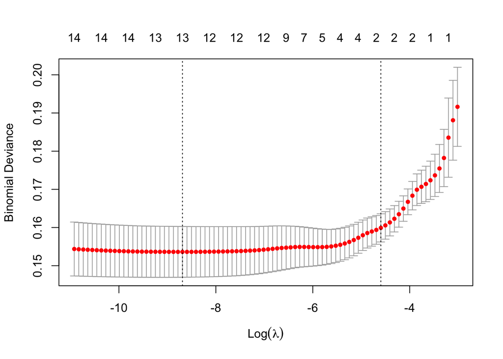

```r
pos = function(x, s, u = NULL) {
    x = ifelse(x > s, x - s, 0)
    if (!is.null(u))
        x = ifelse(x > (u - s), u - s, x)
    x
}

dtrain = model.matrix(~ age + pos(age, 50) + . - 1,
                      data = data_train %>% select(-outcome))
dvalid = model.matrix(~ age + pos(age, 50) +  . - 1,
                      data = data_valid %>% select(-outcome))
cv_glmnet = cv.glmnet(dtrain, data_train$outcome == 'dead', family = 'binomial', nfolds = 5,
                   type.measure = 'deviance', keep = TRUE)
plot(cv_glmnet)
```

Coefficients for best model

```r
best_ind = which(cv_glmnet$lambda == cv_glmnet$lambda.min)
beta = cv_glmnet$glmnet.fit$beta[, best_ind]
beta
```

```
##                         age                pos(age, 50)
##                1.727311e-02                3.173849e-02
##                   sexfemale                     sexmale
##               -1.661608e-01                2.729571e-16
##                countryother        countryUnited States
##               -1.438834e+00               -5.005588e-01
##            chronic_disease1           chronic_diseaseNA
##                5.438701e+00                2.126397e+00
## `pneumonia|pneumonitis`TRUE                    painTRUE
##               -2.145555e+00                0.000000e+00
##                   feverTRUE                   coughTRUE
##                3.961498e-02               -2.171434e+00
##           `sore throat`TRUE                 fatigueTRUE
##                0.000000e+00                1.424374e+00
##                headacheTRUE                 dyspneaTRUE
##                0.000000e+00                2.943456e+00
```

Log-odds histogram for Logistic Lasso on validation data

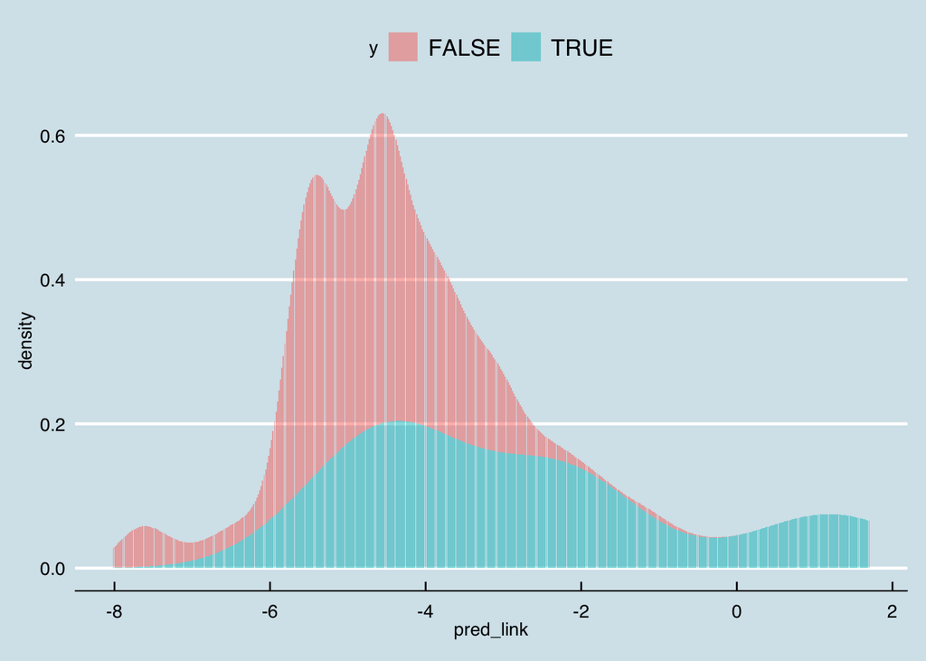

```r
pred_data = tibble(y = data_valid$outcome == 'dead',
       pred_link = predict(cv_glmnet, dvalid, type='link', s = 'lambda.min'),
       pred = predict(cv_glmnet, dvalid, type='response', s = 'lambda.min'))
pred_data %>%
    ggplot(aes(pred_link, fill = y)) +
    geom_histogram(stat = 'density', alpha = 0.5)
```

1. For the selected data set, train at least one tree-based ensemble model (random forest, gbm, catboost or any other boosting)

Fit XGBoost model with monotonicity constraint for age with the same dataset as Logistic Lasso

```r
dtrain_xgb = xgb.DMatrix(dtrain, label = ifelse(data_train$outcome == 'dead', 1, 0))
dvalid_xgb = xgb.DMatrix(dvalid, label = ifelse(data_valid$outcome == 'dead', 1, 0))

params = list()
params['monotone_constraints'] = '(1, 1, 0, 0, 0, 0, 0, 0, 0, 0, 0, 0, 0, 0, 0, 0)'
watchlist <- list(train=dtrain_xgb, test=dvalid_xgb)
bst  = xgb.train(params = params, data = dtrain_xgb, max_depth = 3, eta = 0.3, nrounds = 35, nthread = 2,
               objective = "binary:logistic", scale_pos_weight = 1, eval_metric = 'logloss',
               watchlist = watchlist)
```

Log-odds histogram for XGBoost model on validation data

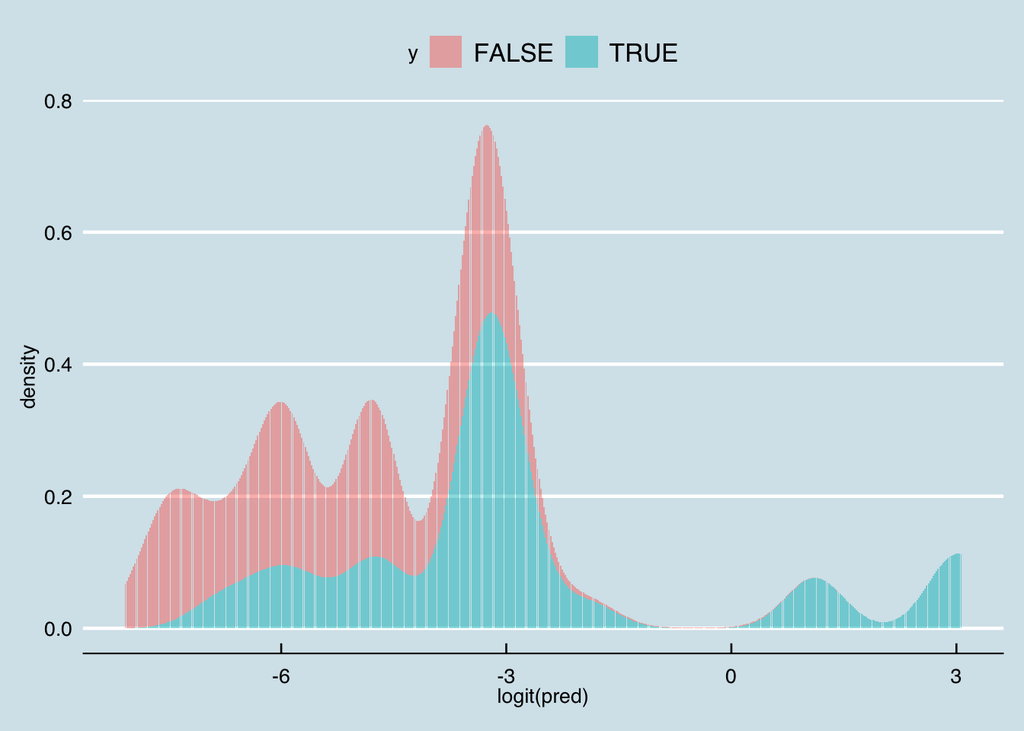

```r
logit <- function(x) log(x / (1 - x))

pred_data = tibble(y = data_valid$outcome == 'dead',
       pred = predict(bst, dvalid_xgb, type='prob'))
pred_data %>%
    ggplot(aes(logit(pred), fill = y)) +
    geom_histogram(stat = 'density', alpha = 0.5)
```

Use DALEX library to create explainers :-) and show validation metrics - cutoff selected manually, but it’s not that important.

GLM and XGB have similar F1, but the threshold has not been optimized.

XGB looks slightly better on validation data under the AUC metric

```r
xgb_perf = DALEX::model_performance(xgb_explain, cutoff = th)
cv_glmnet_perf = DALEX::model_performance(cv_glmnet_explain, cutoff = th)
xgb_perf
```

```
## Measures for:  classification
## recall   : 0.1851852
## precision: 0.625
## f1       : 0.2857143
## accuracy : 0.9817651
## auc      : 0.8027723
##
## Residuals:
##           0%          10%          20%          30%          40%
## -94.53380013  -3.88531052  -3.55778076  -2.45118365  -0.79791499
##          50%          60%          70%          80%          90%
##  -0.72487886  -0.26369998  -0.19754779  -0.10623251  -0.05603426
##         100%
##   0.89376749
```

```r
cv_glmnet_perf
```

```
## Measures for:  classification
## recall   : 0.1851852
## precision: 0.8333333
## f1       : 0.3030303
## accuracy : 0.9832239
## auc      : 0.792328
##
## Residuals:
##          0%         10%         20%         30%         40%         50%
## -83.5636950  -3.4658897  -2.0916190  -1.4090238  -1.1002789  -0.9118439
##         60%         70%         80%         90%        100%
##  -0.6496687  -0.4764362  -0.3969057  -0.3125574   0.5665555
```

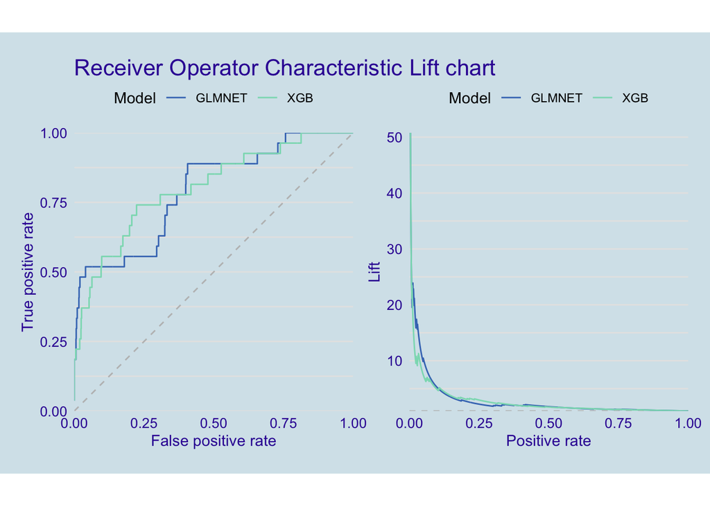

```r
p1 <- plot(cv_glmnet_perf, xgb_perf, geom = "roc")
p2 <- plot(cv_glmnet_perf, xgb_perf, geom = "lift")

library(patchwork)
p1 + p2
```

2. for some selected observation from this dataset, calculate the model predictions for model (1)

```r
example = data_valid[12, ]
example
```

| age | sex | country | chronic_disease | outcome | pneumonia\|pneumonitis | pain | fever | cough | sore throat | fatigue | headache | dyspnea |
| --- | --- | --- | --- | --- | --- | --- | --- | --- | --- | --- | --- | --- |
| 52 | female | United States | NA | recovered | FALSE | FALSE | FALSE | FALSE | FALSE | FALSE | FALSE | FALSE |

```r
xgb_predict(bst, example %>% select(-outcome))
```

```
## [1] 3.885311
```

XGB model predicts 3.88% mortality rate for a 52 year old woman from US, no knowledge on chronic diseases is present. The person recovered.

3. for an observation selected in (2), calculate the decomposition of model prediction using SHAP, Break Down or both (packages for R: DALEX, iml, packages for python: shap, dalex, piBreakDown).

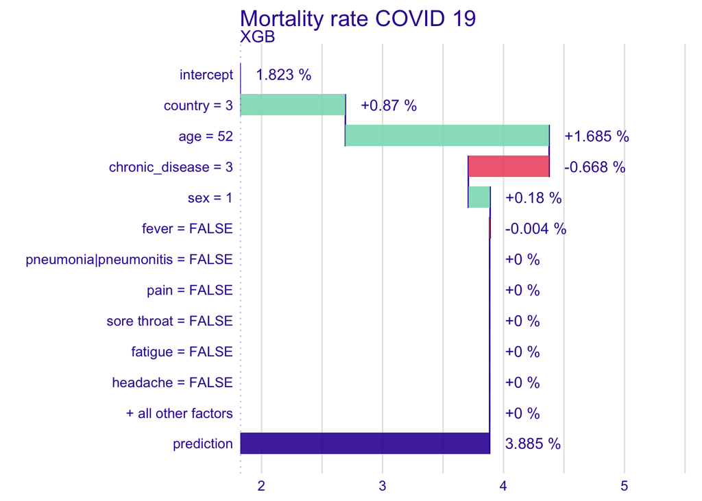

```r
plot_decomposition(xgb_explain, example,type = 'break_down')
```

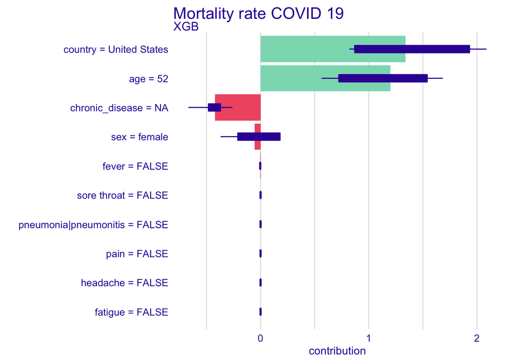

```r
plot_decomposition(xgb_explain, example,type = 'shap')
```

Both SHAP and BreakDown select age and country as the most important variables for this example.

The contribution of age in BreakDown method is slightly higher than in SHAP. Conversely, the contribution of country is higher in SHAP decomposition.

4. find two observations in the data set, such that they have different most important variables (e.g. age and gender are the most important for observation A, but race and class for observation B)

```r
example2 = data_valid[8,]
example3 = data_valid[333,]
example3
```

| age | sex | country | chronic_disease | outcome | pneumonia\|pneumonitis | pain | fever | cough | sore throat | fatigue | headache | dyspnea |
| --- | --- | --- | --- | --- | --- | --- | --- | --- | --- | --- | --- | --- |
| 44 | male | other | 1 | dead | FALSE | FALSE | FALSE | FALSE | FALSE | FALSE | FALSE | FALSE |

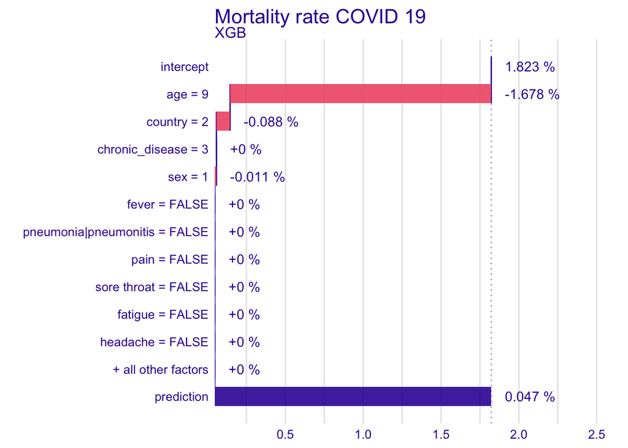

```r
plot_decomposition(xgb_explain, example2, type = 'break_down')
```

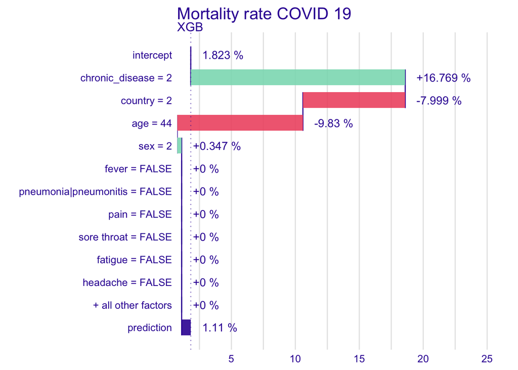

```r
plot_decomposition(xgb_explain, example3, type = 'break_down')
```

We can see that age is the most important variable in first example of a young, healthy person. In the second case, the presence of chronic disease increases mortality rate substantially, but its impact is mitigated by age and country.

5. select one variable and find two observations in the data set such that for one observation this variable has a positive effect and for the other a negative effect

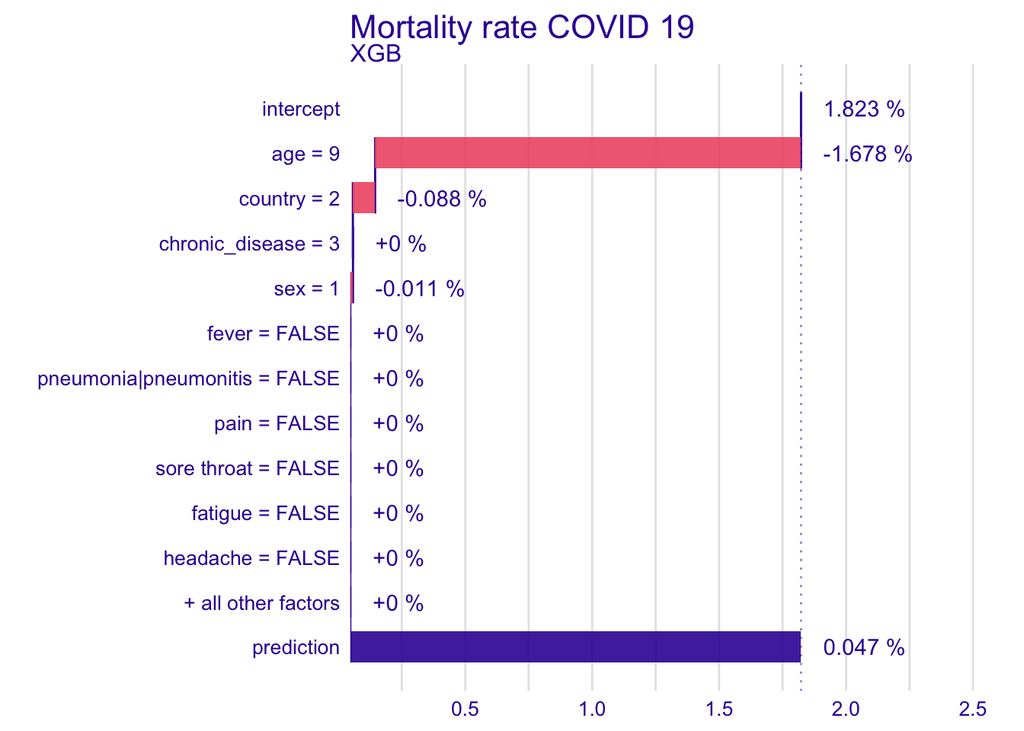

```r
example4 = data_valid[75, ]
plot_decomposition(xgb_explain, example2, type = 'break_down')
```

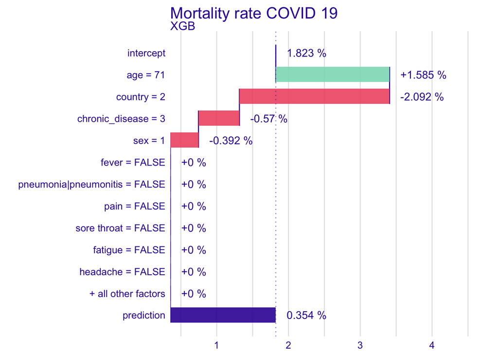

```r
plot_decomposition(xgb_explain, example4, type = 'break_down')
```

We can see that age of 71 increases mortality rate in the second example. Age of 9 decreases the mortality rate to almost 0%.

This is in line with the common knowledge, that older people are a high risk group.

6b) find an observation for which BD/shap attributions are different between the models

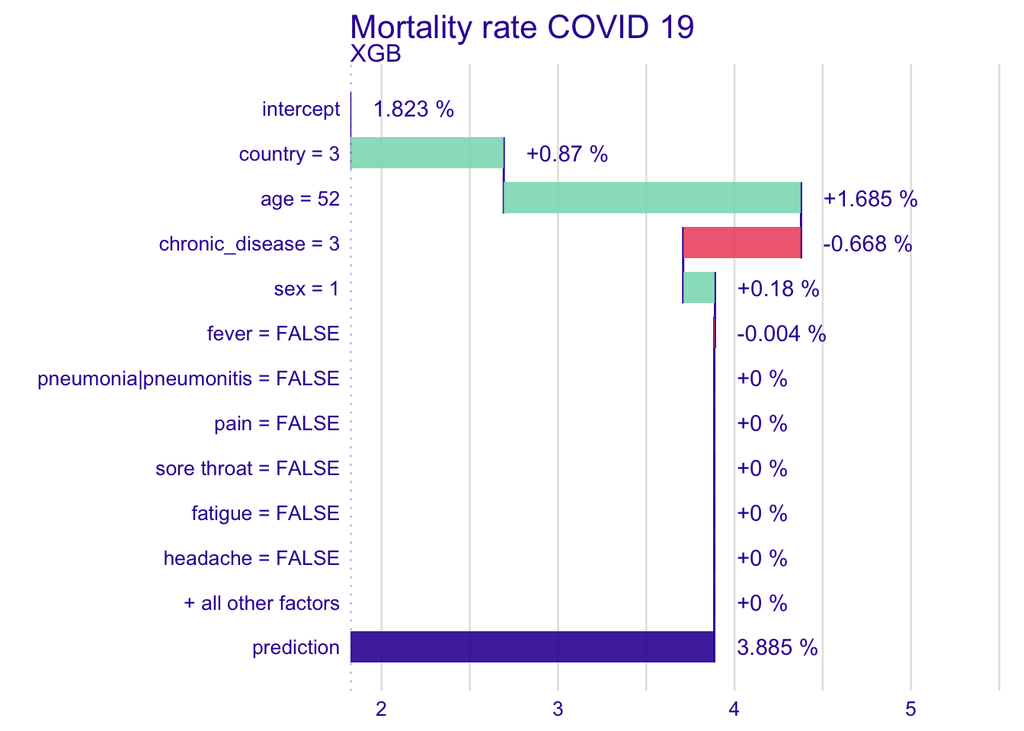

```r
plot_decomposition(xgb_explain, example, type = 'break_down')
```

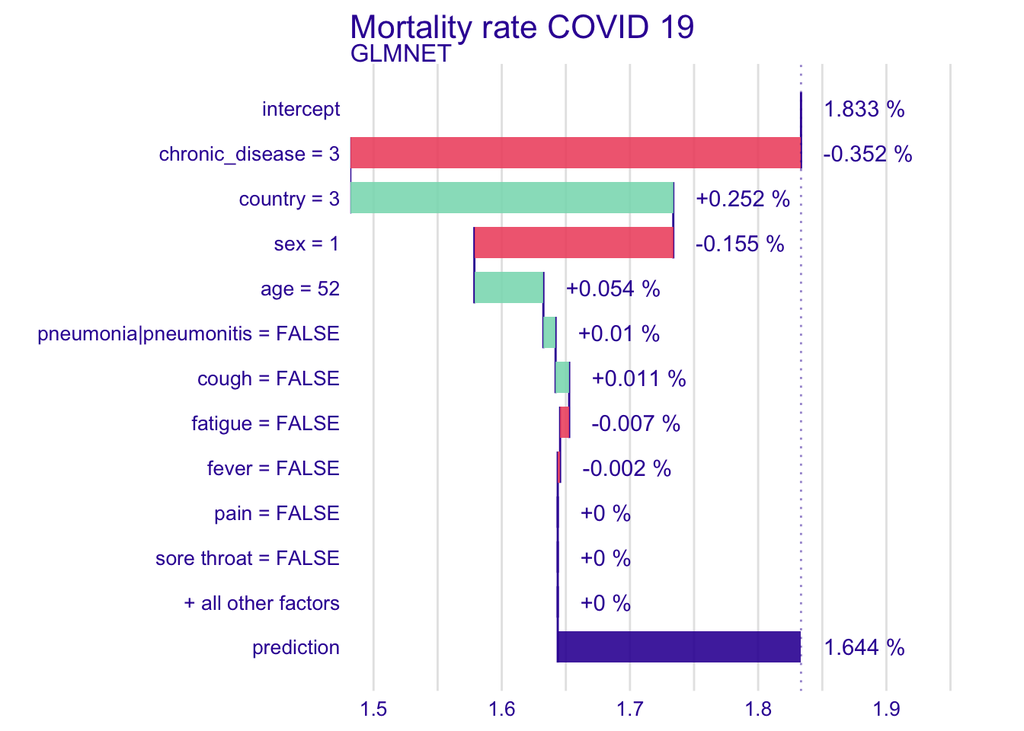

```r
plot_decomposition(cv_glmnet_explain, example, type = 'break_down')
```

We can see that the prediction and variable attributions differ substantially. Sex has an increasing impact on mortality in XGB model, but negative in GLMNET model. Impact of age is also substantially lower in GLMNET model. GLMNET also assigns small, but non-zero, importance to early symptoms whereas XGB ignores them.

Age profiles for XGB and GLMNET models, we can see that the monotonicity constraint for age is working.

```r
prof = DALEX::individual_profile(xgb_explain, example)
```

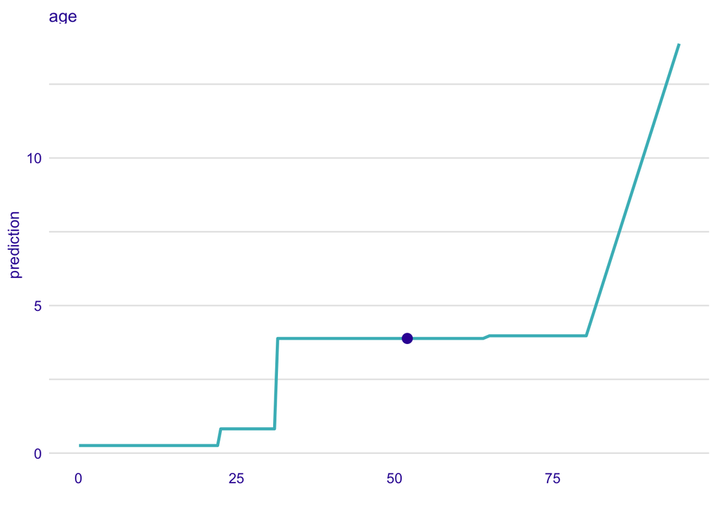

```r
plot(prof, variables = 'age')
```

```r
prof = DALEX::individual_profile(cv_glmnet_explain, example)
```

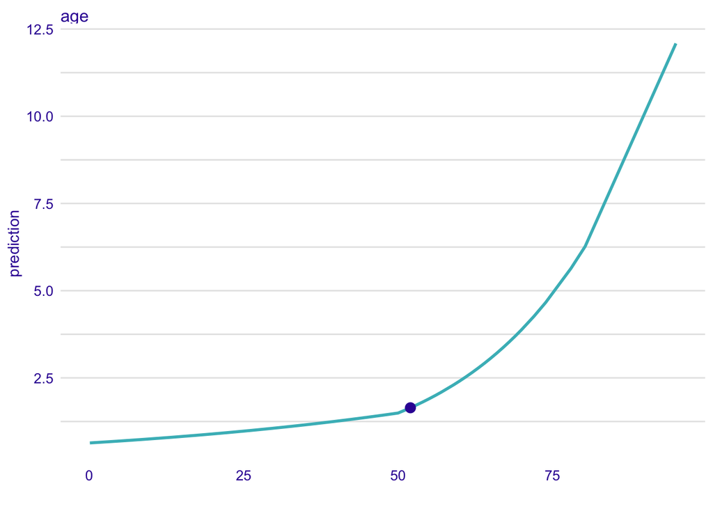

```r
plot(prof, variables = 'age')
```